# **Assignment 4: Clustering and classification**

In this analysis I will use the Boston data set available at https://stat.ethz.ch/R-manual/R-devel/library/MASS/html/Boston.html. The data contains information on 14 variables describing the housing values in 506 suburbs of Boston. Here I will focus on the per capita crime rate (crim) and study if there is correspondence to any other variable. To conduct this analysis, different methods to cluster and classify the observations are tested.

```r
# load boston data and check contents
data("Boston")
summary(Boston)
```

```
##       crim                zn             indus            chas
##  Min.   : 0.00632   Min.   :  0.00   Min.   : 0.46   Min.   :0.00000
##  1st Qu.: 0.08205   1st Qu.:  0.00   1st Qu.: 5.19   1st Qu.:0.00000
##  Median : 0.25651   Median :  0.00   Median : 9.69   Median :0.00000
##  Mean   : 3.61352   Mean   : 11.36   Mean   :11.14   Mean   :0.06917
##  3rd Qu.: 3.67708   3rd Qu.: 12.50   3rd Qu.:18.10   3rd Qu.:0.00000
##  Max.   :88.97620   Max.   :100.00   Max.   :27.74   Max.   :1.00000
##       nox               rm             age              dis
##  Min.   :0.3850   Min.   :3.561   Min.   :  2.90   Min.   : 1.130
##  1st Qu.:0.4490   1st Qu.:5.886   1st Qu.: 45.02   1st Qu.: 2.100
##  Median :0.5380   Median :6.208   Median : 77.50   Median : 3.207
##  Mean   :0.5547   Mean   :6.285   Mean   : 68.57   Mean   : 3.795
##  3rd Qu.:0.6240   3rd Qu.:6.623   3rd Qu.: 94.08   3rd Qu.: 5.188
##  Max.   :0.8710   Max.   :8.780   Max.   :100.00   Max.   :12.127
##       rad              tax           ptratio          black
##  Min.   : 1.000   Min.   :187.0   Min.   :12.60   Min.   :  0.32
##  1st Qu.: 4.000   1st Qu.:279.0   1st Qu.:17.40   1st Qu.:375.38
##  Median : 5.000   Median :330.0   Median :19.05   Median :391.44
##  Mean   : 9.549   Mean   :408.2   Mean   :18.46   Mean   :356.67
##  3rd Qu.:24.000   3rd Qu.:666.0   3rd Qu.:20.20   3rd Qu.:396.23
##  Max.   :24.000   Max.   :711.0   Max.   :22.00   Max.   :396.90
##      lstat            medv
##  Min.   : 1.73   Min.   : 5.00
##  1st Qu.: 6.95   1st Qu.:17.02
##  Median :11.36   Median :21.20
##  Mean   :12.65   Mean   :22.53
##  3rd Qu.:16.95   3rd Qu.:25.00
##  Max.   :37.97   Max.   :50.00
```

Distributions and correlations of different variables are shown below. The distribution of crime rates resembles logarithmic distribution with mostly very low crime rates. The distributions of other variables are also skewed. This may cause problems when linear discriminate analysis and clustering is applied as one of the assumptions behind the method is normally distributed observations.

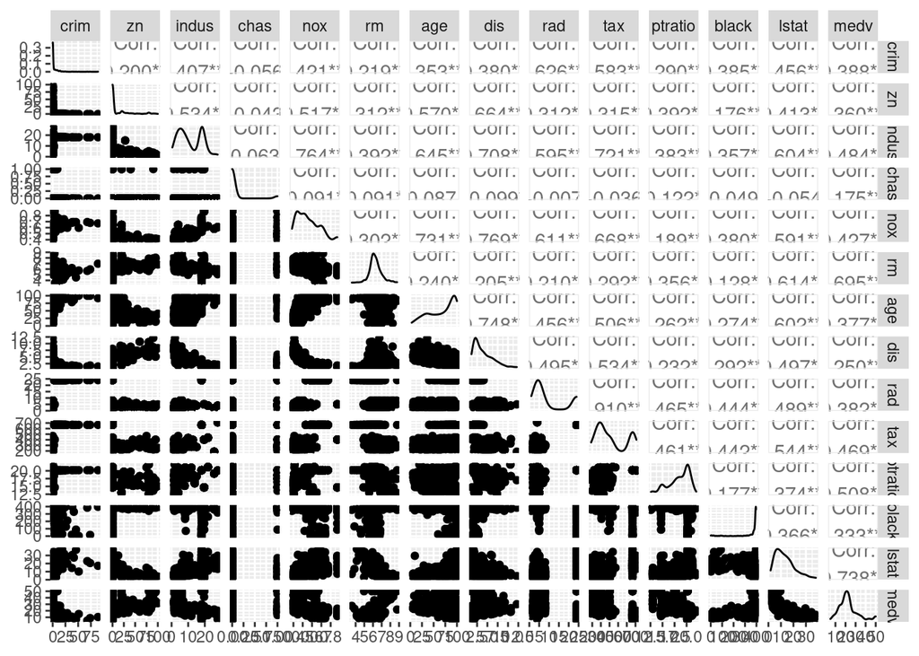

```r
ggpairs(Boston, lower = list(combo = wrap("facethist", bins = 20)))
```

Strong negative correlation is seen between weighted mean of distances to five Boston employment centres (dis) and proportion of owner-occupied units built prior to 1940 (age). With growing distance the proportion of old houses decreases, which is likely due to the fact that the old houses are concentrated near the center. Newer houses were build further away from the center as the city expanded. Distance is negatively correlated also with concentration of nitrogen oxides (nox), which means the pollution level decreases with growing distance from the city centers. Also the proportion of non-retail business acres per town (indus) decreases further away from the centers. These are really not relevant for the analysis conducted here, so I will not go deeper into the other variables but concentrate on the crime rate.

```r
# calculate the correlation matrix and round it
cor_matrix<-cor(Boston) %>% round(digits = 2)

# print the correlation matrix
cor_matrix
```

```
##          crim    zn indus  chas   nox    rm   age   dis   rad   tax ptratio
## crim     1.00 -0.20  0.41 -0.06  0.42 -0.22  0.35 -0.38  0.63  0.58    0.29
## zn      -0.20  1.00 -0.53 -0.04 -0.52  0.31 -0.57  0.66 -0.31 -0.31   -0.39
## indus    0.41 -0.53  1.00  0.06  0.76 -0.39  0.64 -0.71  0.60  0.72    0.38
## chas    -0.06 -0.04  0.06  1.00  0.09  0.09  0.09 -0.10 -0.01 -0.04   -0.12
## nox      0.42 -0.52  0.76  0.09  1.00 -0.30  0.73 -0.77  0.61  0.67    0.19
## rm      -0.22  0.31 -0.39  0.09 -0.30  1.00 -0.24  0.21 -0.21 -0.29   -0.36
## age      0.35 -0.57  0.64  0.09  0.73 -0.24  1.00 -0.75  0.46  0.51    0.26
## dis     -0.38  0.66 -0.71 -0.10 -0.77  0.21 -0.75  1.00 -0.49 -0.53   -0.23
## rad      0.63 -0.31  0.60 -0.01  0.61 -0.21  0.46 -0.49  1.00  0.91    0.46
## tax      0.58 -0.31  0.72 -0.04  0.67 -0.29  0.51 -0.53  0.91  1.00    0.46
## ptratio  0.29 -0.39  0.38 -0.12  0.19 -0.36  0.26 -0.23  0.46  0.46    1.00
## black   -0.39  0.18 -0.36  0.05 -0.38  0.13 -0.27  0.29 -0.44 -0.44   -0.18
## lstat    0.46 -0.41  0.60 -0.05  0.59 -0.61  0.60 -0.50  0.49  0.54    0.37
## medv    -0.39  0.36 -0.48  0.18 -0.43  0.70 -0.38  0.25 -0.38 -0.47   -0.51
##         black lstat  medv
## crim    -0.39  0.46 -0.39
## zn       0.18 -0.41  0.36
## indus   -0.36  0.60 -0.48
## chas     0.05 -0.05  0.18
## nox     -0.38  0.59 -0.43
## rm       0.13 -0.61  0.70
## age     -0.27  0.60 -0.38
## dis      0.29 -0.50  0.25
## rad     -0.44  0.49 -0.38
## tax     -0.44  0.54 -0.47
## ptratio -0.18  0.37 -0.51
## black    1.00 -0.37  0.33
## lstat   -0.37  1.00 -0.74
## medv     0.33 -0.74  1.00
```

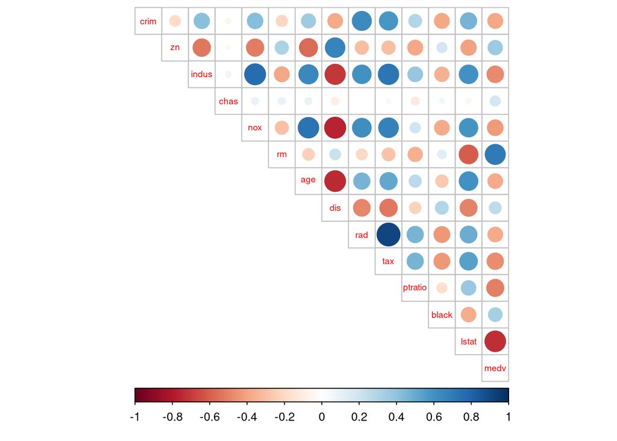

```r
# visualize the correlation matrix
corrplot(cor_matrix, method="circle", type="upper", cl.pos="b", tl.pos="d", tl.cex = 0.6)
```

First, the dataset is standardized in order to make the variables comparable when conducting classification. As seen from the summaries below, the standardized values are centered around zero. However, the scaling does not influence the original distribution and thus it can be seen from the histogram that the distribution of the scaled crime rate remains logarithmic.

```r
# center and standardize variables
boston_scaled <- scale(Boston)

# change the object to data frame
boston_scaled = as.data.frame(boston_scaled)

# summary of the scaled crime rate
summary(boston_scaled)
```

```
##       crim                 zn               indus              chas
##  Min.   :-0.419367   Min.   :-0.48724   Min.   :-1.5563   Min.   :-0.2723
##  1st Qu.:-0.410563   1st Qu.:-0.48724   1st Qu.:-0.8668   1st Qu.:-0.2723
##  Median :-0.390280   Median :-0.48724   Median :-0.2109   Median :-0.2723
##  Mean   : 0.000000   Mean   : 0.00000   Mean   : 0.0000   Mean   : 0.0000
##  3rd Qu.: 0.007389   3rd Qu.: 0.04872   3rd Qu.: 1.0150   3rd Qu.:-0.2723
##  Max.   : 9.924110   Max.   : 3.80047   Max.   : 2.4202   Max.   : 3.6648
##       nox                rm               age               dis
##  Min.   :-1.4644   Min.   :-3.8764   Min.   :-2.3331   Min.   :-1.2658
##  1st Qu.:-0.9121   1st Qu.:-0.5681   1st Qu.:-0.8366   1st Qu.:-0.8049
##  Median :-0.1441   Median :-0.1084   Median : 0.3171   Median :-0.2790
##  Mean   : 0.0000   Mean   : 0.0000   Mean   : 0.0000   Mean   : 0.0000
##  3rd Qu.: 0.5981   3rd Qu.: 0.4823   3rd Qu.: 0.9059   3rd Qu.: 0.6617
##  Max.   : 2.7296   Max.   : 3.5515   Max.   : 1.1164   Max.   : 3.9566
##       rad               tax             ptratio            black
##  Min.   :-0.9819   Min.   :-1.3127   Min.   :-2.7047   Min.   :-3.9033
##  1st Qu.:-0.6373   1st Qu.:-0.7668   1st Qu.:-0.4876   1st Qu.: 0.2049
##  Median :-0.5225   Median :-0.4642   Median : 0.2746   Median : 0.3808
##  Mean   : 0.0000   Mean   : 0.0000   Mean   : 0.0000   Mean   : 0.0000
##  3rd Qu.: 1.6596   3rd Qu.: 1.5294   3rd Qu.: 0.8058   3rd Qu.: 0.4332
##  Max.   : 1.6596   Max.   : 1.7964   Max.   : 1.6372   Max.   : 0.4406
##      lstat              medv
##  Min.   :-1.5296   Min.   :-1.9063
##  1st Qu.:-0.7986   1st Qu.:-0.5989
##  Median :-0.1811   Median :-0.1449
##  Mean   : 0.0000   Mean   : 0.0000
##  3rd Qu.: 0.6024   3rd Qu.: 0.2683
##  Max.   : 3.5453   Max.   : 2.9865
```

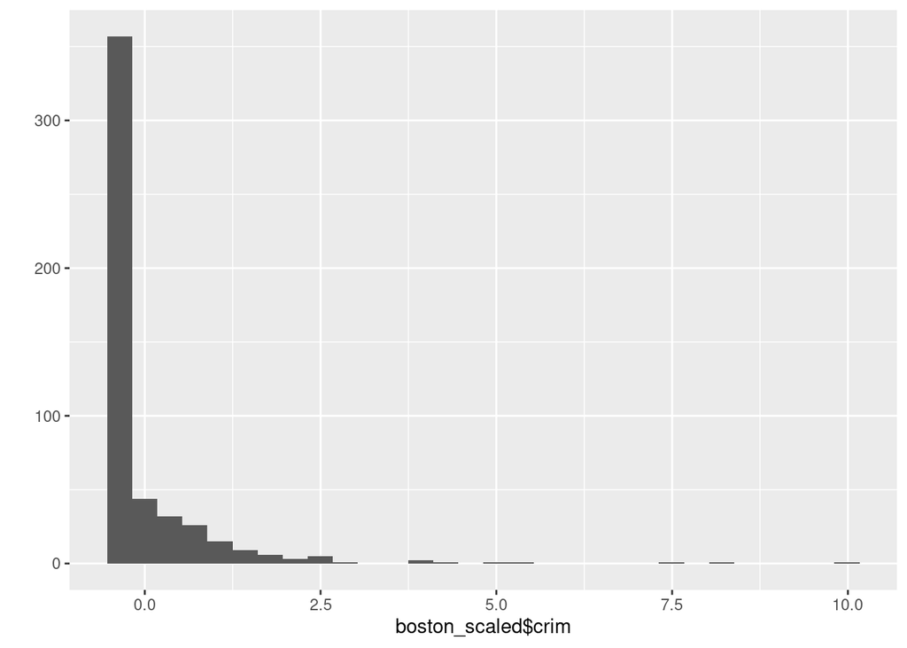

```r
# plot histogram to see the distribution of scaled crime rate
qplot(boston_scaled$crim, geom="histogram")
```

Next the scaled crime rate is categorized using quantiles as the break points. From the distribution it was already seen that most of the areas in Boston had very low crime rates, making the use of quantiles in categorizing the data questionable. Labeling the categories with equal amount of observations as low, med_low, med_high and high is thus a bit misleading as most of the suburbs have very low crime rate.

```r
# create a quantile vector of crim
bins <- quantile(boston_scaled$crim)

# create a categorical variable 'crime'
crime <- cut(boston_scaled$crim, breaks = bins, include.lowest = TRUE, labels = c("low", "med_low", "med_high", "high"))

# look at the table of the new factor crime
table(crime)
```

```
## crime
##      low  med_low med_high     high
##      127      126      126      127
```

```r
# remove original crim from the dataset
boston_scaled <- dplyr::select(boston_scaled, -crim)

# add the new categorical value to scaled data
boston_scaled <- data.frame(boston_scaled, crime)
```

Despite the distribution, I go on fitting linear discriminant analysis on the data. Before that the data is divided into train and test sets. The train set consists of 80 % of the observations.

```r
# number of rows in the Boston dataset
n <- nrow(boston_scaled)

# choose randomly 80% of the rows
ind <- sample(n,  size = n * 0.8)

# create train set
train <- boston_scaled[ind,]

# create test set
test <- boston_scaled[-ind,]

# save the correct classes from test data
correct_classes <- test$crim

# remove the crime variable from test data
test <- dplyr::select(test, -crime)
```

For data classification, the linear discriminant analysis is fitted on the train set with categorical crime rate as the target variable and all the other variables as predictor variables. The fit is shown in the figure below. As can be seen from the figure, the four categories (low, med_low, med_high, high) form two clusters. Of these categories med_high (green) is divided between these two clusters. Therefore, it seems that two categories could be enough to represent the data: low and high crime rates.

```r
# linear discriminant analysis
lda.fit <- lda(crime ~ ., data = train)

# print the lda.fit object
lda.fit
```

```
## Call:
## lda(crime ~ ., data = train)
##
## Prior probabilities of groups:
##       low   med_low  med_high      high
## 0.2623762 0.2500000 0.2475248 0.2400990
##
## Group means:
##                  zn      indus          chas        nox         rm        age
## low       1.0694830 -0.9004687 -0.0866167924 -0.8985383  0.4866409 -0.8883497
## med_low  -0.1108978 -0.2578810  0.0005392655 -0.5576212 -0.1744831 -0.3282988
## med_high -0.3654691  0.1147785  0.2001229606  0.3510162  0.1157182  0.3913515
## high     -0.4872402  1.0172187 -0.0287970943  1.0602702 -0.4147753  0.8302819
##                 dis        rad        tax    ptratio      black       lstat
## low       0.8942064 -0.6915041 -0.7378218 -0.4727408  0.3813212 -0.76705564
## med_low   0.3460576 -0.5486376 -0.4656231 -0.0988244  0.3080968 -0.06332002
## med_high -0.3521822 -0.3881138 -0.3200906 -0.3087993  0.1130060  0.01938602
## high     -0.8844407  1.6371072  1.5133254  0.7795879 -0.7829317  0.90144106
##                 medv
## low       0.57423995
## med_low  -0.01260991
## med_high  0.19769198
## high     -0.68486620
##
## Coefficients of linear discriminants:
##                 LD1           LD2         LD3
## zn       0.09717868  0.8761086230 -0.83178555
## indus   -0.03105184 -0.1298308866  0.26381692
## chas    -0.06014806 -0.0893345205  0.03794684
## nox      0.40828494 -0.6105843318 -1.46453462
## rm      -0.06869794 -0.0493092469 -0.14633346
## age      0.30273957 -0.2296333372 -0.23600431
## dis     -0.08163652 -0.2770974272  0.09566425
## rad      2.94265880  0.9972989275 -0.02287676
## tax      0.02508176 -0.2040536337  0.68557931
## ptratio  0.13205439  0.1015818853 -0.34138805
## black   -0.14448753  0.0007006891  0.15680682
## lstat    0.20083681 -0.2298534846  0.42012746
## medv     0.16725725 -0.3069663611 -0.20928205
##
## Proportion of trace:
##    LD1    LD2    LD3
## 0.9423 0.0411 0.0166
```

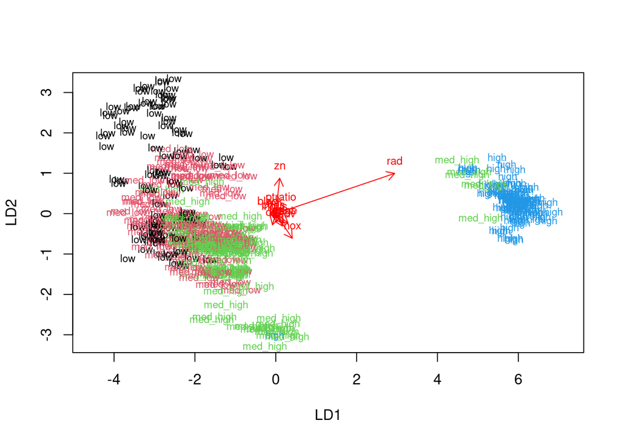

```r
# the function for lda biplot arrows
lda.arrows <- function(x, myscale = 1, arrow_heads = 0.1, color = "red", tex = 0.75, choices = c(1,2)){
  heads <- coef(x)
  arrows(x0 = 0, y0 = 0,
         x1 = myscale * heads[,choices[1]],
         y1 = myscale * heads[,choices[2]], col=color, length = arrow_heads)
  text(myscale * heads[,choices], labels = row.names(heads),
       cex = tex, col=color, pos=3)
}

# target classes as numeric
classes <- as.numeric(train$crime)

# plot the lda results
plot(lda.fit, dimen = 2, col = classes, pch = classes)
lda.arrows(lda.fit, myscale = 1)
```

The linear discriminant analysis model fitted to the train dataset is used to predict the classes of the test data. The results are shown in the table below with comparison to the correct categories. It is seen that the majority of the results lie on the diagonal, meaning that the prediction matches the original categories rather well. There are no predictions that are completely off as the values in the bottom left and top right corners are zeros. Although the model seems to perform reasonably well, there are some discrepancies.

```r
# predict classes with test data
lda.pred <- predict(lda.fit, newdata = test)

# cross tabulate the results
table(correct = correct_classes, predicted = lda.pred$class)
```

```
##           predicted
## correct    low med_low med_high high
##   low        9      11        1    0
##   med_low    5      15        5    0
##   med_high   0       4       22    0
##   high       0       0        0   30
```

Because the linear discriminant analysis showed that perhaps only two categories are needed, Euklidean distance is calculated to represent similarities between observations and K-means clustering is applied to investigate the optimal number of categories. From the figure below it is seen that as the curve decreases strongly around value 2, two categories are sufficient to represent the similarities within the data.

```r
# reload the Boston dataset
data("Boston")

# center and standardize variables
boston_scaled <- scale(Boston)

# change the object to data frame
boston_scaled = as.data.frame(boston_scaled)

# euclidean distance matrix
dist_eu <- dist(boston_scaled)

# look at the summary of the distances
summary(dist_eu)
```

```
##    Min. 1st Qu.  Median    Mean 3rd Qu.    Max.
##  0.1343  3.4625  4.8241  4.9111  6.1863 14.3970
```

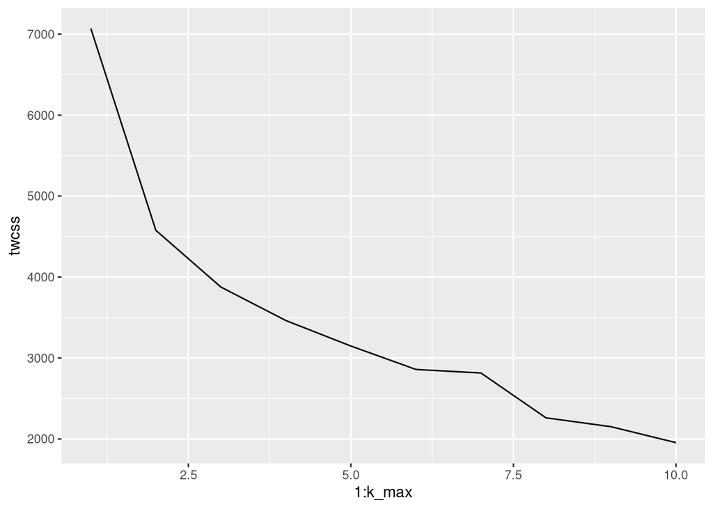

```r
# k-means clustering
km <-kmeans(boston_scaled, centers = 3)

set.seed(123)

# determine the number of clusters
k_max <- 10

# calculate the total within sum of squares
twcss <- sapply(1:k_max, function(k){kmeans(boston_scaled, k)$tot.withinss})

# visualize the results
qplot(x = 1:k_max, y = twcss, geom = 'line')
```

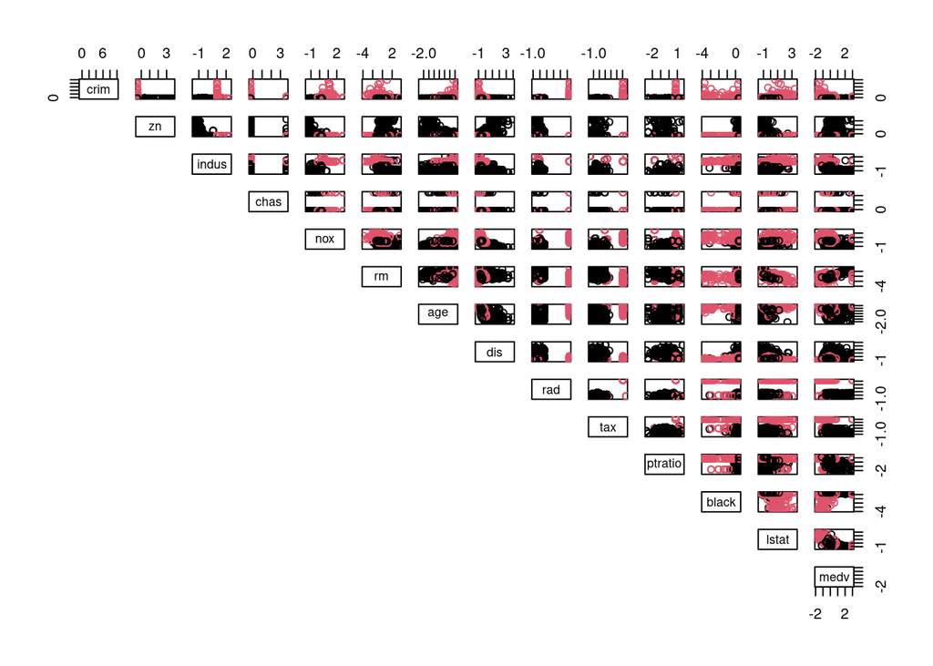

```r
# k-means clustering
km <-kmeans(boston_scaled, centers = 2)

# plot the Boston dataset with clusters
pairs(boston_scaled, col = km$cluster, lower.panel = NULL)
```

Grouping with two centers (above) can be compared to grouping with three centers shown below. With three groups there are some overlapping with centers.

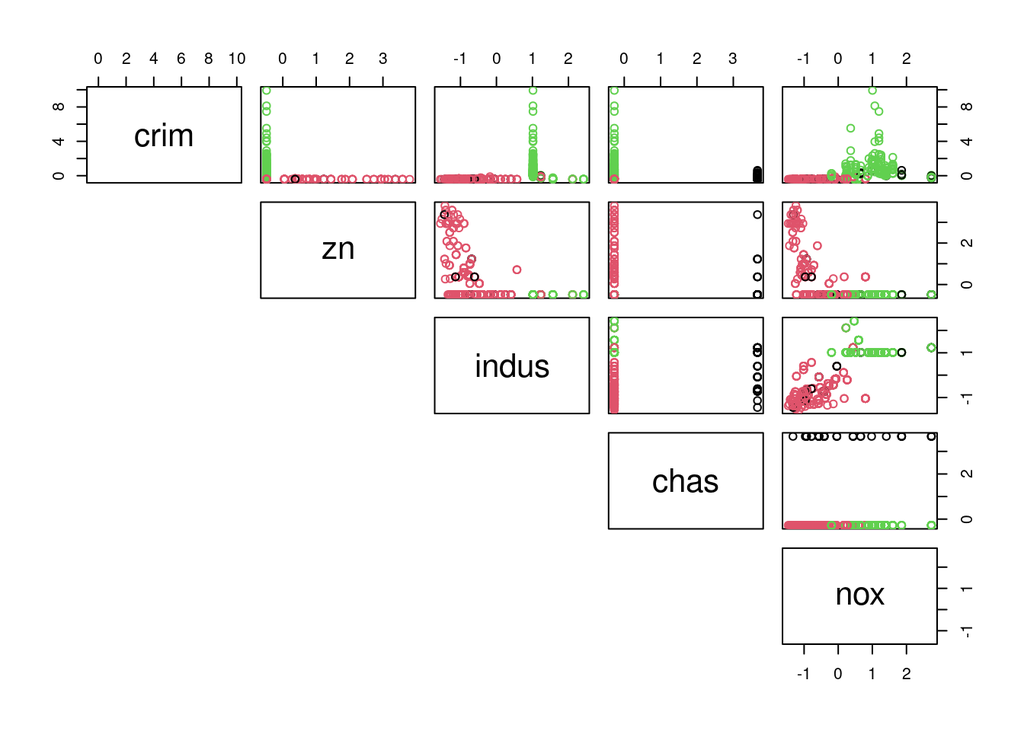

```r
# k-means clustering
km <-kmeans(boston_scaled, centers = 3)

# plot the Boston dataset with clusters
pairs(boston_scaled[1:5], col = km$cluster, lower.panel = NULL)
```

```r
date()
```

```
## [1] "Sun Nov 28 15:36:22 2021"
```